# SLAM Glucose, Body Weight, and Body Comp

Eric Shiroma, John Nam

2020 April 07

## Study Description

- This is an investigation into the longitudinal trajectories of glucose, body weight, and body composition in SLAM (a mouse cohort). These results will be used to compare similar trajectories in humans and monkeys.

## Analysis

#### census data read in

- input file census.csv (10/30/2019)
- edit csv column name ‘Animal_ID’

#### body weight data read in and clean

- input file BW_Temp_FC_All_2019-11-16 (11/16/2019)
- clean body weights (funny values)
  - text to missing
  - bw < 10 to missing

#### glucose data read in and clean

- input file Glucose_Lactate.csv (10/30/2019)
- edit csv column name ‘Stress_Notes’
- clean glucose (funny values)
  - text to missing
  - gluc < 20 or gluc >= 500 to missing

#### body comp data read in and clean

- input file NMR.csv (10/30/2019)
- clean bodycomp (funny values)
  - text to missing
  - fat <= 0 to missing

#### survival data read in and clean

- input file Survival.csv (10/30/2019)
- clean survival (funny values)
  - text to missing
  - recode old to new idnos

#### merging all datasets into a main file and clean

- glucose
- bodywt (body weight)
- bodycomp (body composition)
- census
- removal of timepoints before dob

#### restriction to cohorts 1 to 6

#### population characteristics

- 1241 mice with valid indices
- 50.20 % female
- 50.04 % B6

#### age characteristics

Age Characteristics

| group1 | n | mean | sd | median | trimmed | mad | min | max | range | skew | kurtosis | se |
| --- | --- | --- | --- | --- | --- | --- | --- | --- | --- | --- | --- | --- |
| all | 1241 | 13.42 | 4.58 | 14 | 13.54 | 0.64 | 4.14 | 113.14 | 109.00 | 13.12 | 244.53 | 0.13 |
| F | 623 | 13.92 | 4.21 | 14 | 13.69 | 0.64 | 11.14 | 72.43 | 61.29 | 12.91 | 176.59 | 0.17 |
| M | 618 | 12.91 | 4.88 | 14 | 13.39 | 0.64 | 4.14 | 113.14 | 109.00 | 13.54 | 284.91 | 0.20 |
| B6 | 621 | 13.73 | 4.13 | 14 | 13.56 | 0.64 | 12.00 | 113.14 | 101.14 | 22.40 | 535.80 | 0.17 |
| HET3 | 620 | 13.10 | 4.98 | 14 | 13.51 | 0.64 | 4.14 | 72.43 | 68.29 | 7.72 | 95.39 | 0.20 |

#### frequencies of measures

Assessment Frequencies

| indices | n | mean | sd | median | trimmed | mad | min | max | range | skew | kurtosis | se |
| --- | --- | --- | --- | --- | --- | --- | --- | --- | --- | --- | --- | --- |
| glucose | 1241.00 | 6.37 | 2.45 | 7.00 | 6.65 | 1.48 | 0.00 | 11.00 | 11.00 | -0.93 | 0.00 | 0.07 |
| body weight | 1241.00 | 39.41 | 17.01 | 43.00 | 40.82 | 16.31 | 0.00 | 79.00 | 79.00 | -0.64 | -0.41 | 0.48 |
| fat | 1241.00 | 7.94 | 3.38 | 9.00 | 8.27 | 2.97 | 0.00 | 21.00 | 21.00 | -0.81 | 0.01 | 0.10 |

#### census_c16_death creation

- merge
  - census
  - surv
  - main_all2
  - restrict to cohorts 1 to 6
  - remove mice with missing time of death
  - create all cause death censor category
    - all-cause mortality included: “Found dead”, “Per PI”, “Culled”, “DVR or Pathology”, “Culled Per Vet”

#### cause of death

Cause of Death

| Cause of Death | Frequency |
| --- | --- |
| Cage flood | 4 |
| Culled | 13 |
| Culled Per Vet | 129 |
| Died during experiment | 4 |
| Died during procedure | 25 |
| DVR or Pathology | 54 |
| End of study, organs removed | 214 |
| Euthanized | 21 |
| Found dead | 468 |
| Not in room | 40 |
| Other | 1 |
| Per PI | 111 |
| Per Vet | 1 |
| undefined | 1 |
| Used in experiment | 155 |

#### death frequency

Death Frequency

| Dead = 1 | Frequency |
| --- | --- |
| 0 | 465 |
| 1 | 776 |

#### follow up time

Follow Up Time

| vars | n | mean | sd | median | trimmed | mad | min | max | range | skew | kurtosis | se |
| --- | --- | --- | --- | --- | --- | --- | --- | --- | --- | --- | --- | --- |
| 1.00 | 1241.00 | 90.65 | 37.40 | 102.00 | 94.53 | 29.65 | -97.00 | 169.00 | 266.00 | -0.93 | 0.54 | 1.06 |

#### life expectancy

Life Expectancy

|  | Sex | Total | Dead | Life Expectancy (weeks) | sd |
| --- | --- | --- | --- | --- | --- |
| 1 | all | 1241 | 776 | 111.29 | 25.44 |
| 2 | female | 623 | 390 | 111.49 | 25.01 |
| 3 | male | 618 | 386 | 111.09 | 25.90 |
| 4 | HET3 | 620 | 371 | 111.89 | 25.86 |
| 5 | B6 | 621 | 405 | 110.75 | 25.07 |

#### age at peak indices value creation

#### main_cat2 creation

- merge
  - main_all2
  - census_c16_death
- create categories by survival length
  - needed for survival bias sensitivity

#### main_all3 creation

- merge
  - main_all2
  - census_c16_death
  - main_cat2

## Results

#### distribution figure with trend line

- generalized additive model for main indices
- linear model with quadratic fit for lifespan groups (survival bias analyses)

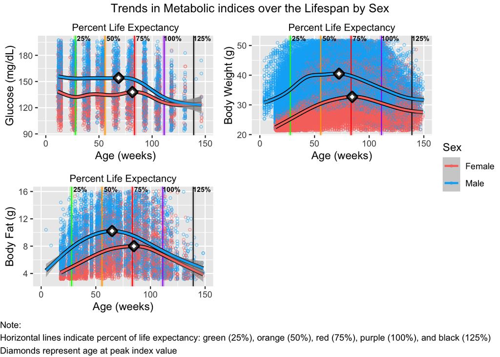

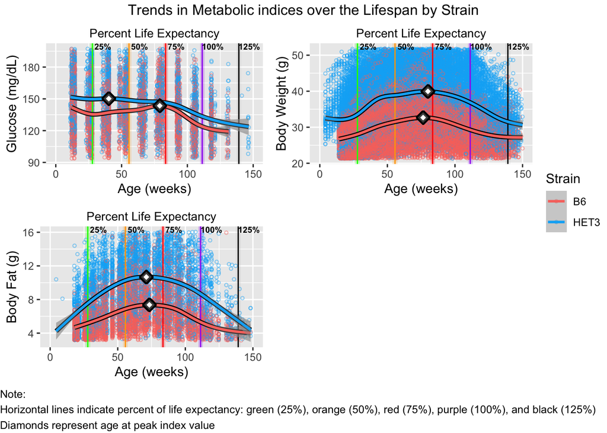

#### pre and post-peak change creation

#### change in metabolic indices pre and post-peak

- rate of percent change

Rate of Percent Change for Metabolic indices Pre- and Post-peak

| Metabolic Index | Age at Peak Value$^†$ (% life expectancy) All | Age at Peak Value$^†$ (% life expectancy) Female | Age at Peak Value$^†$ (% life expectancy) Male | Pre-Peak$^‡$$^§$ All | Pre-Peak$^‡$$^§$ Female | Pre-Peak$^‡$$^§$ Male | Post-Peak$^‡$$^§$ All | Post-Peak$^‡$$^§$ Female | Post-Peak$^‡$$^§$ Male |
| --- | --- | --- | --- | --- | --- | --- | --- | --- | --- |
| gluc | 70.35 (60.59, 82.67) | 73.04 (61.38, 83.42) | 61.6 (24.3, 82.82) | 0.25 ( 0.15, 0.34)* | 0.44 ( 0.32, 0.55)* | 0.05 (-0.08, 0.19) | -1.59 (-1.81, -1.36)* | -1.20 (-1.53, -0.87)* | -1.73 (-1.97, -1.50)* |
| bw | 71.11 (65.59, 76.38) | 75.73 (69.06, 82.64) | 65.2 (52.34, 71.24) | 1.96 ( 1.90, 2.02)* | 2.97 ( 2.91, 3.04)* | 1.91 ( 1.85, 1.98)* | -1.54 (-1.63, -1.45)* | -1.48 (-1.60, -1.37)* | -1.72 (-1.81, -1.64)* |
| fat | 63.92 (55.58, 75.35) | 76.11 (63.42, 86.37) | 58.39 (49, 69.31) | 5.15 ( 4.88, 5.43)* | 6.20 ( 5.87, 6.53)* | 4.76 ( 4.41, 5.11)* | -3.55 (-3.69, -3.41)* | -4.20 (-4.92, -3.48)* | -3.59 (-4.03, -3.15)* |

* p value < 0.05  
† Mean (range of ages at similar values) of age at peak index value  
‡ Mean (95% confidence interval) rate of percent change during phase per five percent change in life expectancy  
<sup>§</sup> Pre-peak is defined as 25% life expectancy to age at peak value; post-peak phase is defined as peak to 125% life expectancy  
<sup>¶</sup> Male and female estimates are based on sex specific life expectancy

#### kaplan meier survival curves

- comparing highest to lowest quartile
- three timepoints: 50, 75, and 100% life expectancy

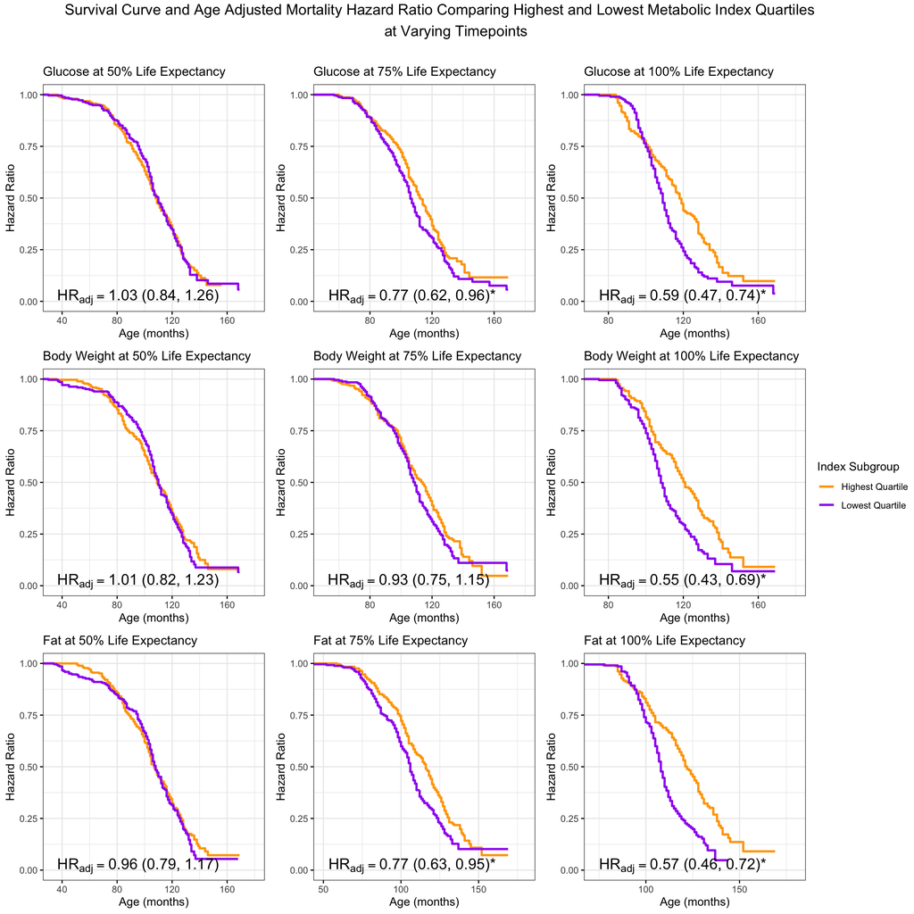

#### cox proportional mortality hazard ratios

- sex specific
- covariate adjustment
  - sex, age
  - additional adjustment for body fat

Mortality Hazard Ratios of Highest and Lowest Glucose Quartiles at Varying Timepoints Stratified by Sex

| Timepoint | All Model 1 | All Model 2 | Female Model 1 | Female Model 2 | Male Model 1 | Male Model 2 |
| --- | --- | --- | --- | --- | --- | --- |
| 50 | 1.03 (0.84, 1.26) | 1.05 (0.84, 1.31) | 1.01 (0.75, 1.35) | 1.10 (0.80, 1.50) | 1.05 (0.79, 1.41) | 0.99 (0.71, 1.37) |
| 75 | 0.77 (0.62, 0.95)* | 0.91 (0.72, 1.15) | 0.81 (0.59, 1.09) | 0.93 (0.66, 1.29) | 0.73 (0.54, 1.00)* | 0.88 (0.63, 1.23) |
| 100 | 0.58 (0.46, 0.73)* | 0.93 (0.69, 1.25) | 0.41 (0.28, 0.58)* | 0.62 (0.41, 0.95)* | 0.66 (0.48, 0.90)* | 1.04 (0.67, 1.62) |

* p-value < 0.05  
† Hazard ratios (95% confidence intervals) are adjusted for: Model 1) age and sex; Model 2) additionally adjusted for body composition

Mortality Hazard Ratios of Highest and Lowest Body Weight and Composition Quartiles at Varying Timepoints Stratified by Sex

| Metabolic Index | Timepoint$^†$ | All | Female | Male |
| --- | --- | --- | --- | --- |
| Body Weight | 50 | 1.01 (0.83, 1.23) | 0.88 (0.66, 1.17) | 1.15 (0.86, 1.54) |
|  | 75 | 0.93 (0.75, 1.15) | 0.92 (0.68, 1.24) | 0.94 (0.70, 1.26) |
|  | 100 | 0.54 (0.43, 0.69)* | 0.45 (0.31, 0.64)* | 0.54 (0.39, 0.75)* |
| Body Composition | 50 | 0.96 (0.79, 1.17) | 0.80 (0.60, 1.06) | 1.15 (0.86, 1.54) |
|  | 75 | 0.78 (0.63, 0.96)* | 0.74 (0.54, 0.99)* | 0.81 (0.61, 1.09) |
|  | 100 | 0.58 (0.46, 0.73)* | 0.59 (0.43, 0.82)* | 0.57 (0.41, 0.80)* |

* p-value < 0.05  
† Hazard ratios are adjusted for age and sex  
‡ Timepoint is percent of mean life expectancy

## Author Questions

#### determine assessments over lifespan

Assessments of Metabolic indices Over the Lifespan

| Timepoint$^†$ | Population New Participants | Population Alive | Population Dead | Glucose Measured | Glucose Imputed | Glucose Missing | Body Weight Measured | Body Weight Imputed | Body Weight Missing | Body Composition Measured | Body Composition Imputed | Body Composition Missing |
| --- | --- | --- | --- | --- | --- | --- | --- | --- | --- | --- | --- | --- |
| 25 | 717 | 1235 | 118 | 1180 | 0 | 55 | 1170 | 0 | 65 | 1174 | 0 | 61 |
| 50 | 0 | 1121 | 114 | 1041 | 56 | 24 | 1118 | 3 | 0 | 1106 | 13 | 2 |
| 75 | 3 | 1007 | 185 | 906 | 77 | 24 | 997 | 10 | 0 | 979 | 26 | 2 |
| 100 | 1 | 822 | 457 | 725 | 87 | 10 | 814 | 8 | 0 | 651 | 170 | 1 |
| 125 | 0 | 365 | 365 | 91 | 274 | 0 | 350 | 15 | 0 | 154 | 211 | 0 |

* Imputation using last observed value carried forward  
† Timepoint is percent of mean life expectancy

#### trajectories by varying survival groups

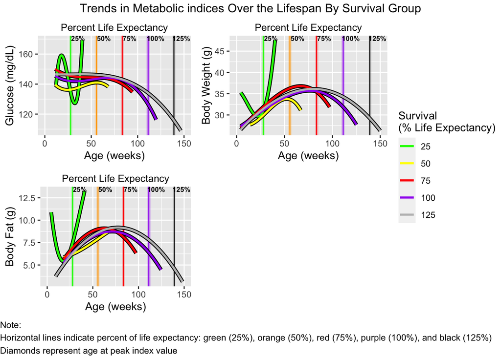